# Modelo lineal generalizado (GLM)

MSc. Darío ALvarado

Los modelos lineales generalizados utilizan una regresión lineal ordinaria que permite analizar variables respuesta que tienen una distribución de errores distintos a una distribución normal (gausiana).

### GLM con distribución de Poisson

Los modelos con distribución de Poisson son utilizados para analizar datos cuando la variable respuesta tiene una alta cantidad de ceros (modelo influenciado por ceros), son especialmente útiles para analizar datos de conteos (0, 1, 2, 3, 4…).

#### Paquetes

```r
library(tidyverse)
library(sjPlot)
library(performance)
library(parameters)
library(bbmle)
library(modelbased)
library(agridat)
library(MASS)
library(rio)
```

### Contenido

#### Datos

Trabajaremos con los datos de “beall.webworms” del paquete `agridat`

```r
data("beall.webworms")
worms <- beall.webworms
head(worms)
```

```
##   row col y block trt spray lead
## 1   1   1 1    B1  T1     N    N
## 2   2   1 0    B1  T1     N    N
## 3   3   1 1    B1  T1     N    N
## 4   4   1 3    B1  T1     N    N
## 5   5   1 6    B1  T1     N    N
## 6   6   1 0    B2  T1     N    N
```

Esta base de dados contiene información de conteos de larvas de *Hyphantria cunea*, una polilla (Lepidoptera) de la familia Erebidae catalogada como plaga que se caracteriza por la construcción de nidos en forma de redes en las ramas de las plantas de cultivo que afecta disminuyendo su rendimiento.

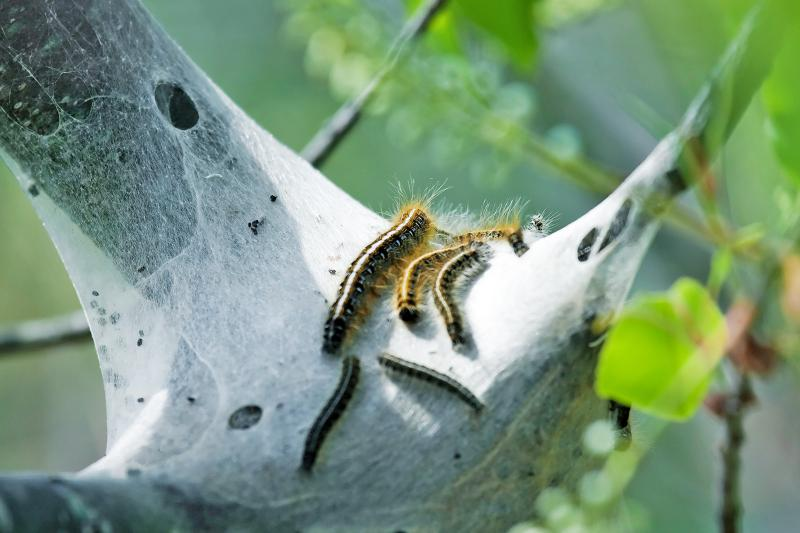

Los datos provienen de un experimiento con un diseño de bloques en donde se evaluaron cuatro tratamientos (variable “trt”):

- “T1” : control (sin tratamiento)
- “T2”: aplicación de insecticidad de contacto
- “T3”: aplicación de arsenato de plomo
- “T4”: aplicación combinada de insecticida y arsenato de plomo

La variable “spray” tiene dos niveles:

- “Y”: se aplicó insecticida
- “N”: No se aplicó insecticida

Y la variable “lead” tiene dos niveles:

- “Y”: se aplicó arsenato de plomo
- “N”: No se aplicó arsenato de plomo

##### Exploración de datos

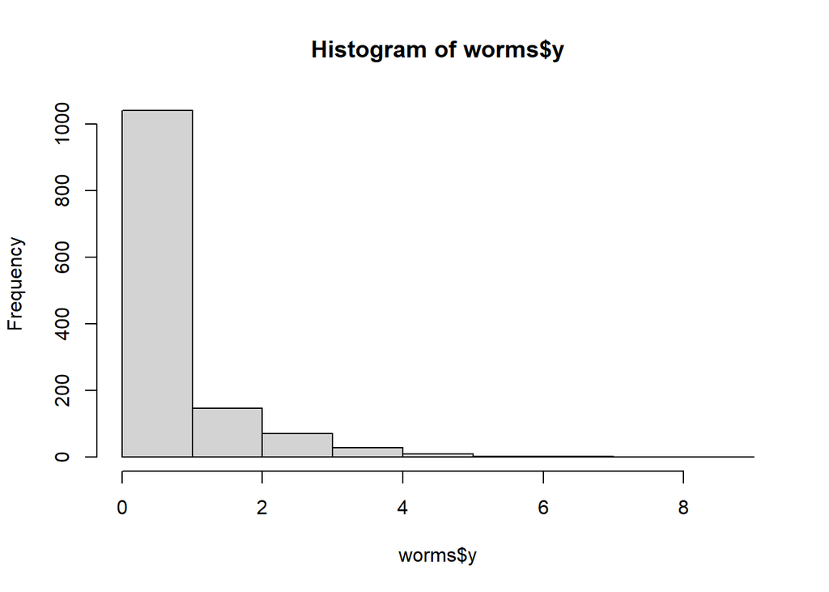

```r
hist(worms$y)
```

La variable y (conteo de larvas) tiene una distribución discreta (Poisson) con mucha influencia de ceros

Volver Arriba

Inicio

#### Modelo

Para realizar un modelo lineal generalizado (GLM) utilizamos la función `glm()` del paquete base. Un GLM puede analizar una variable respuesta que tenga una distribución diferente a la distribución normal (gausiana), solamente tenemos que indicar la distribución de los datos con el argumento `family =`

```r
glm1 <- glm(y ~ spray, data = worms, family = poisson)
```

**En un GLM con distribución de Poisson hay una transformación logarítmica interna en el modelo. La distribución de Poisson utiliza un enlace log (link = log)**

##### Coeficientes del modelo

```r
summary(glm1)
```

```
##
## Call:
## glm(formula = y ~ spray, family = poisson, data = worms)
##
## Coefficients:
##             Estimate Std. Error z value Pr(>|z|)
## (Intercept)  0.11881    0.03696   3.214  0.00131 **
## sprayY      -0.89869    0.06871 -13.079  < 2e-16 ***
## ---
## Signif. codes:  0 '***' 0.001 '**' 0.01 '*' 0.05 '.' 0.1 ' ' 1
##
## (Dispersion parameter for poisson family taken to be 1)
##
##     Null deviance: 1955.9  on 1299  degrees of freedom
## Residual deviance: 1767.2  on 1298  degrees of freedom
## AIC: 3168.2
##
## Number of Fisher Scoring iterations: 5
```

Los coeficientes del modelo con distribución de Poisson están en escala logarítmica.

- El intercepto es la media de la variable respuesta para el primer nivel de la variable predictora categórica o el valor de la variable respuesta en el eje y cuando la variable predictora numérica en el eje x es igual a cero. En este caso, la media de conteo de larvas por unidad de muestreo cuando NO se aplica insecticida (“sprayN”) es de 0.11881 (en escala logarítmica).

Para interpretar el coeficiente tenemos que exponenciarlo (aplicar el antilogaritmo):

```r
exp(0.11881)
```

```
## [1] 1.126156
```

Ahora si se puede interpretar con el valor en unidades de la variable respuesta:

La media de conteo de larvas por unidad de muestreo cuando NO se aplica insecticida (sprayN) es de 1.13.

- El coeficiente de “sprayY” NO indica la media de conteo cuando si se aplica insecticida:

```r
exp(-0.89869)
```

```
## [1] 0.4071026
```

Este coeficiente **es un factor de disminución o aumento** por el que se multiplica un valor X de la variable respuesta. Indica por cuánto aumenta o disminuye la variable respuesta por el factor de la variable predictora.

Si el factor es 1 = no hay incremento o disminución (el valor X de la variable respuesta se multiplica por 1). Si el factor es de 1.5 = el aumento es de 50%. Si el factor es de 1.05 = el aumento es de 5% Si el factor es de 0.9 = hay una disminución del 10%

*Ejemplo de aumento de salario:*

Si nuestro salario es de $1000 y nos dicen que el siguiente mes recibiremos un aumento por un factor de 1.5:

```r
1000*1.5
```

```
## [1] 1500
```

Nuestro salario aumentará 50%.

Si nos dicen que el factor de aumento es de 1, el salario será el mismo porque se estará multiplicando por 1.

Si el factor es menor a 1, el salario disminuirá en lugar de aumentar:

```r
1000*0.8
```

```
## [1] 800
```

Volviendo a los datos de las larvas, el factor de 0.41 nos está indicando que cuando se aplica insecticida (“sprayY”), la cantidad de orugas disminuirá por un factor de 0.41. Esto quiere decir que la disminución será del 59% (1 - 0.41 = 0.59).

Si tenemos 10 larvas por unidad de muestreo cuando no se aplica insecticida, ¿cuál será la cantidad de larvas que podríamos encontrar cuando si se aplicó insecticida:

```r
10*0.41
```

```
## [1] 4.1
```

- En el summary ya no aparecen valores de R cuadrado múltiple o R cuadrado ajustado como en los modelos lineales.
- Aparecen valores de **desviación nula** que indica cuánta variabilidad hay en los datos antes de incluir las variables explicativas, y nos sirve como punto de referencia; y la **desviación residual** que indica cuánta variabilidad no es explicada por el modelo y qué tan bien se ajustan las predicciones a los datos observados. Entre más baja la desviación residual respecto a la desviación nula, mejor es el ajuste.
- También aparece el valor de AIC del modelo en caso de realizar una selección de modelos.

La función `parameters()` incorpora el argumento `exponentiate =` para que nos muestre los coeficientes reales y no en escala logarítmica:

```r
parameters(glm1,
           exponentiate = TRUE)
```

```
## Parameter   |  IRR |   SE |       95% CI |      z |      p
## ----------------------------------------------------------
## (Intercept) | 1.13 | 0.04 | [1.05, 1.21] |   3.21 | 0.001
## spray [Y]   | 0.41 | 0.03 | [0.36, 0.47] | -13.08 | < .001
```

```
##
## Uncertainty intervals (profile-likelihood) and p-values (two-tailed)
##   computed using a Wald z-distribution approximation.
```

Verificamos el ajuste del modelo con la función `performance()` del paquete `performance`

```r
performance(glm1)
```

```
## # Indices of model performance
##
## AIC    |   AICc |    BIC | Nagelkerke's R2 |  RMSE | Sigma | Score_log | Score_spherical
## ----------------------------------------------------------------------------------------
## 3168.2 | 3168.2 | 3178.6 |           0.174 | 1.085 |     1 |    -1.217 |           0.025
```

El resultado nos muestra los valores de AIC, AICc y BIC que ya vimos en los modelos lineales.

También muestra un valor de pseudo R cuadrado que puede calcularse con diferentes métodos (por defecto utiliza el método de Nagelkerke).

El RMSE y el Sigma se interpretan de la misma forma que en los modelos lineales.

Volver Arriba

Inicio

#### Gráfico del modelo

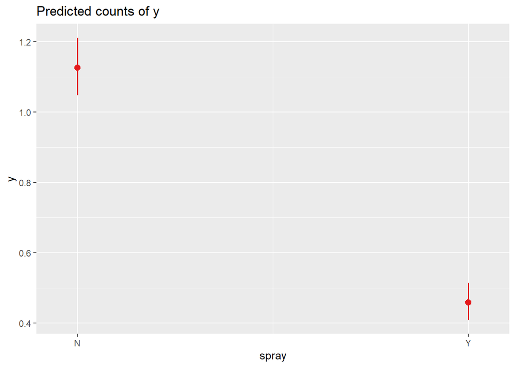

```r
plot_model(glm1,
           type = "pred",
           terms = "spray")
```

En el gráfico observamos que el intercepto del modelo indica la media de la cantidad de larvas cuando no se aplicó insecticida, y el punto cuando si se aplicó insecticida también indica la media de la cantidad de larvas.

Para determinar esa media con los datos de la salida del modelo tenemos que multiplicar el intercepto por el factor de disminución:

```r
1.13*0.41
```

```
## [1] 0.4633
```

La media de la cantidad de larvas cuando se aplica insecticida es de 0.46 (para una cantidad de 1.13 orugas cuando no se aplica insecticida).

Volver Arriba

Inicio

#### Validación del modelo

Un GLM con distribución de Poisson debe cumplir algunos supuestos diferentes a los de un modelo lineal.

Debemos evaluar la **sobredispersión** del modelo. Para eso utilizamos la función `check_overdispersion()` del paquete `performance`

```r
check_overdispersion(glm1)
```

```
## # Overdispersion test
##
##        dispersion ratio =    1.405
##   Pearson's Chi-Squared = 1824.284
##                 p-value =  < 0.001
```

```
## Overdispersion detected.
```

Aquí observamos si el valor de “dispersion ratio” es igual o mayor a 1. El resultado debería ser igual a 1 o lo más cercano a 1 (1.00…). Si el resultado es mayor a 1, nuestro modelo presenta sobredispersión.

El valor de p indica la significancia de la sobredispersión, p < 0.05 = la sobredispersión es significativa; p >= 0.05 = la sobredispersión NO es significativa.

La prueba también nos da el resultado de forma textual en la parte inferior: “Overdispersion detected”

También se puede calcular la sobredispersión de forma manual dividiendo la desviación residual (Residual deviance en el summary del modelo) entre los grados de libertad. El resultado varía un poco respecto al “dispersion ratio” de la función `check_overdispersion()`, pero la interpretación es la misma, el resultado debería ser 1 o lo más cercano a 1.

```r
1767.2 / 1298
```

```
## [1] 1.361479
```

Cuando hay sobredispersión en el modelo, los coeficientes están bien, pero el error estándar y los intervalos de confianza están subestimados.

También se debe evaluar la inflación de ceros que presenta el modelo. Para eso utilizamos la función `check_zeroinflation()` del paquete `performance`:

```r
check_zeroinflation(glm1)
```

```
## # Check for zero-inflation
##
##    Observed zeros: 711
##   Predicted zeros: 622
##             Ratio: 0.87
```

```
## Model is underfitting zeros (probable zero-inflation).
```

Esta función compara los ceros predichos por el modelo contra los ceros observados y calcula una tasa dividiéndolos. Si la cantidad de ceros observados es igual que la de ceros predichos, la tasa es de 1 (no hay inflación de ceros). La cantidad de ceros observados no necesariamente tiene que ser igual a la de ceros predichos, pero ese valor debe estar dentro de un rango tolerable para que no se detecte inflación de ceros.

Volver Arriba

Inicio

#### Correción de modelos

Cuando el modelo con distribución de Poisson tiene problemas de sobredispersión se puede corregir mediante modelos con distribución quasiPoisson o con distribución binomial negativa.

##### Modelo con distribución quasipoisson

```r
glm1_q <- glm(y ~ spray,
               data = worms,
               family = quasipoisson) # solo cambiamos la familia de "poisson" a "quasipoisson"
```

Ahora comparemos los parámetros:

```r
parameters(glm1,
           exponentiate = TRUE,
           digits = 4, # para indicar la cantidad de decimales del error estándar
           ci_digits = 4) # para indicar la cantidad de decimales del intervalo de confianza
```

```
## Parameter   |    IRR |     SE |           95% CI |        z |      p
## --------------------------------------------------------------------
## (Intercept) | 1.1262 | 0.0416 | [1.0465, 1.2097] |   3.2145 | 0.001
## spray [Y]   | 0.4071 | 0.0280 | [0.3553, 0.4652] | -13.0795 | < .001
```

```
##
## Uncertainty intervals (profile-likelihood) and p-values (two-tailed)
##   computed using a Wald z-distribution approximation.
```

```r
parameters(glm1_q,
           exponentiate = TRUE,
           digits = 4,
           ci_digits = 4)
```

```
## Parameter   |    IRR |     SE |           95% CI |  t(1298) |      p
## --------------------------------------------------------------------
## (Intercept) | 1.1262 | 0.0493 | [1.0322, 1.2257] |   2.7113 | 0.007
## spray [Y]   | 0.4071 | 0.0332 | [0.3464, 0.4768] | -11.0321 | < .001
```

```
##
## Uncertainty intervals (profile-likelihood) and p-values (two-tailed)
##   computed using a Wald t-distribution approximation.
```

Los coeficientes seguirán siendo los mismos, lo que cambia es el error estándar y los intervalos de confianza. Un modelo con sobredispersión e inflación de ceros subestima el error estándar, para eso se corrige con la función quasipoisson.

##### Modelo con distribución binomial negativa

Para realizar un modelo con distribución binomial negativa utilizamos la función `glm.nb()` del paquete `MASS`

```r
glm1_bn <- glm.nb(y ~ spray,
              data = worms)
```

Ahora comparamos los parámetros.

```r
parameters(glm1_bn,
           exponentiate = TRUE,
           digits = 4,
           ci_digits = 4)
```

```
## Parameter   |    IRR |     SE |           95% CI |        z |      p
## --------------------------------------------------------------------
## (Intercept) | 1.1262 | 0.0533 | [1.0261, 1.2352] |   2.5105 | 0.012
## spray [Y]   | 0.4071 | 0.0327 | [0.3474, 0.4762] | -11.1735 | < .001
```

```
##
## Uncertainty intervals (profile-likelihood) and p-values (two-tailed)
##   computed using a Wald z-distribution approximation.
```

Este modelo realiza corrección similar a la del modelo con distribución quasipoisson sobre el error estándar y los intervalos de confianza.

Cuándo utilizar cada tipo de corrección:

- quasipoisson:
  - cuando la sobredispersión es moderada
  - cuando no se requiera hacer selección de modelos con base en AIC
- binomial negativa:
  - cuando la sobredispersión es muy fuerte
  - cuando se realizará selección de modelos con base en AIC
  - cuando el modelo tenga inflación de ceros

Volver Arriba

Inicio

#### Selección de modelos

```r
glm0 <- glm(y ~ 1, data = worms, family = poisson)
glm1 <- glm(y ~ spray, data = worms, family = poisson)
glm2 <- glm(y ~ trt, data = worms, family = poisson)
glm3 <- glm(y ~ lead, data = worms, family = poisson)
glm4 <- glm(y ~ spray + lead, data = worms, family = poisson)
glm5 <- glm(y ~ spray * lead, data = worms, family = poisson)
```

Con la función `compare_performance()` del paquete `performance`

```r
compare_performance(glm0, glm1, glm2, glm3, glm4, glm5, rank = TRUE)
```

```
## Following indices with missing values are not used for ranking: Sigma
```

```
## # Comparison of Model Performance Indices
##
## Name | Model | Nagelkerke's R2 |  RMSE | Sigma | Score_log | Score_spherical
## ----------------------------------------------------------------------------
## glm2 |   glm |           0.213 | 1.067 |     1 |    -1.199 |           0.025
## glm5 |   glm |           0.213 | 1.067 |     1 |    -1.199 |           0.025
## glm4 |   glm |           0.209 | 1.068 |     1 |    -1.201 |           0.025
## glm1 |   glm |           0.174 | 1.085 |     1 |    -1.217 |           0.025
## glm3 |   glm |           0.041 | 1.124 |     1 |    -1.273 |           0.026
## glm0 |   glm |           0.000 | 1.135 |     1 |    -1.290 |           0.026
##
## Name | AIC weights | AICc weights | BIC weights | Performance-Score
## -------------------------------------------------------------------
## glm2 |       0.436 |        0.436 |       0.170 |            75.87%
## glm5 |       0.436 |        0.436 |       0.170 |            75.87%
## glm4 |       0.128 |        0.129 |       0.661 |            64.82%
## glm1 |    2.28e-10 |     2.30e-10 |    1.56e-08 |            34.84%
## glm3 |    3.67e-42 |     3.70e-42 |    2.51e-40 |            18.48%
## glm0 |    6.52e-51 |     6.61e-51 |    5.92e-48 |            14.29%
```

La sobredispersión puede afectar la selección de los modelos, y si hubo sobredispersión en nuestro primer modelo es muy propable que también haya en el resto de modelos porque está ligada a la variable respuesta (que es la misma en todos los modelos).

```r
check_overdispersion(glm2)
```

```
## # Overdispersion test
##
##        dispersion ratio =    1.355
##   Pearson's Chi-Squared = 1755.717
##                 p-value =  < 0.001
```

```
## Overdispersion detected.
```

```r
check_overdispersion(glm4)
```

```
## # Overdispersion test
##
##        dispersion ratio =    1.370
##   Pearson's Chi-Squared = 1776.652
##                 p-value =  < 0.001
```

```
## Overdispersion detected.
```

Para evitar que la selección de modelos esté influenciada por la sobredispersión debemos realizarla sobre modelos corregidos:

```r
glm0_q <- glm(y ~ 1, data = worms, family = quasipoisson)
glm1_q <- glm(y ~ spray, data = worms, family = quasipoisson)
glm2_q <- glm(y ~ trt, data = worms, family = quasipoisson)
glm3_q <- glm(y ~ lead, data = worms, family = quasipoisson)
glm4_q <- glm(y ~ spray + lead, data = worms, family = quasipoisson)
glm5_q <- glm(y ~ spray * lead, data = worms, family = quasipoisson)
```

```r
compare_performance(glm0_q, glm1_q, glm2_q, glm3_q, glm4_q, glm5_q, rank = TRUE)
```

```
## # Comparison of Model Performance Indices
##
## Name   | Model | Nagelkerke's R2 |  RMSE | Sigma | Score_log | Score_spherical | Performance-Score
## --------------------------------------------------------------------------------------------------
## glm2_q |   glm |           0.213 | 1.067 | 1.164 |    -1.199 |           0.025 |            81.08%
## glm5_q |   glm |           0.213 | 1.067 | 1.164 |    -1.199 |           0.025 |            81.08%
## glm4_q |   glm |           0.209 | 1.068 | 1.170 |    -1.201 |           0.025 |            77.83%
## glm1_q |   glm |           0.174 | 1.085 | 1.186 |    -1.217 |           0.025 |            64.91%
## glm3_q |   glm |           0.041 | 1.124 | 1.250 |    -1.273 |           0.026 |            30.55%
## glm0_q |   glm |           0.000 | 1.135 | 1.276 |    -1.290 |           0.026 |            20.00%
```

Otra forma de seleccionar los modelos es con la funcion `AICtab` del paquete `bbmle`:

```r
AICtab(glm0, glm1, glm2, glm3, glm4, glm5,
       base = TRUE,
       delta = TRUE,
       sort = TRUE,
       weights = TRUE)
```

```
##      AIC    dAIC   df weight
## glm2 3125.5    0.0 4  0.44
## glm5 3125.5    0.0 4  0.44
## glm4 3127.9    2.5 3  0.13
## glm1 3168.2   42.7 2  <0.001
## glm3 3314.6  189.2 2  <0.001
## glm0 3354.9  229.5 1  <0.001
```

Sin embargo, con esta función no se puede realizar la selección sobre modelos corregidos con la distribución quasipoisson ya que el valor del AIC desaparece cuando se hace esa corrección (“AIC = NA”):

```r
summary(glm1_q)
```

```
##
## Call:
## glm(formula = y ~ spray, family = quasipoisson, data = worms)
##
## Coefficients:
##             Estimate Std. Error t value Pr(>|t|)
## (Intercept)  0.11881    0.04382   2.711  0.00679 **
## sprayY      -0.89869    0.08146 -11.032  < 2e-16 ***
## ---
## Signif. codes:  0 '***' 0.001 '**' 0.01 '*' 0.05 '.' 0.1 ' ' 1
##
## (Dispersion parameter for quasipoisson family taken to be 1.405624)
##
##     Null deviance: 1955.9  on 1299  degrees of freedom
## Residual deviance: 1767.2  on 1298  degrees of freedom
## AIC: NA
##
## Number of Fisher Scoring iterations: 5
```

```r
AICtab(glm0_q, glm1_q, glm2_q, glm3_q, glm4_q, glm5_q,
       base = TRUE,
       delta = TRUE,
       sort = TRUE,
       weights = TRUE)
```

```
##        AIC dAIC df weight
## glm0_q NA  NA   2  NA
## glm1_q NA  NA   3  NA
## glm2_q NA  NA   5  NA
## glm3_q NA  NA   3  NA
## glm4_q NA  NA   4  NA
## glm5_q NA  NA   5  NA
```

Para corregir ese problema podemos ajustar todos los modelos con distribución **binomial negativa** y hacer la selección en base a esos modelos.

Otra forma es haciendo la selección sobre los modelos con distribución de Poisson (sin corrección) colocando un valor de sobredispersión con el argumento `dispersion =`:

```r
AICtab(glm0, glm1, glm2, glm3, glm4, glm5,
       base = TRUE,
       delta = TRUE,
       sort = TRUE,
       weights = TRUE,
       dispersion = 1.370) # para indicar un valor de sobredispersión
```

```
## Warning in ICtab(..., mnames = mnames, type = "AIC"): dispersion!=1, type
## changed to qAIC
```

```
##      qAIC   dqAIC  df weight
## glm2 2283.5    0.0 4  0.39
## glm5 2283.5    0.0 4  0.39
## glm4 2284.8    1.2 3  0.21
## glm1 2313.7   30.1 2  <0.001
## glm3 2420.5  137.0 2  <0.001
## glm0 2449.4  165.9 1  <0.001
```

```r
# El problema aquí es que solo se puede colocar un valor de sobredispersión (de un solo modelo), y ese valor puede alterar la selección. Si colocamos una media de la sobredispersión de todos los modelos también puede alterar el resultado de la selección de modelos.
```

Si observan la advertencia en el resultado de la selección del modelo, nos indica que la dispersión es diferente de 1 (!= 1) y que se cambió el criterio de selección de “AIC” a **“qAIC”**, que está ajustado para los modelos que presentan problemas de sobredispersión.

##### Interpretación del mejor modelo

```r
parameters(glm2_q,
           exponentiate = TRUE)
```

```
## Parameter   |  IRR |   SE |       95% CI | t(1296) |      p
## -----------------------------------------------------------
## (Intercept) | 1.40 | 0.08 | [1.26, 1.56] |    6.17 | < .001
## trt [T2]    | 0.36 | 0.04 | [0.29, 0.44] |   -9.63 | < .001
## trt [T3]    | 0.61 | 0.05 | [0.51, 0.72] |   -5.59 | < .001
## trt [T4]    | 0.29 | 0.03 | [0.23, 0.37] |  -10.69 | < .001
```

```
##
## Uncertainty intervals (profile-likelihood) and p-values (two-tailed)
##   computed using a Wald t-distribution approximation.
```

La media para el conteo de larvas cuando no se aplica tratamiento (T1) es de 1.4 por unidad muestral (IC95% = 1.26, 1.56). Cuando se aplica insecticida de contacto (T2) hay una disminución de larvas por un factor de 0.36 con un IC95% = 0.29, 0.44 (disminución del 64%, IC95% = 71%, 56%); p < 0.001. Cuando se aplica arsenato de plomo (T3) hay una disminución de larvas por un factor de 0.61 con un IC95% = 0.51, 0.72 (disminución del 39%, IC95% = 49%, 28%); p < 0.001. Y cuando se aplica insecticida de contacto combinado con arsenato de plomo (T4) el efecto sobre la cantidad de larvas comparado con el T1 es una disminución por un factor de 0.29 con un IC95% = 0.23, 0.37 (disminución del 71%, IC95% = 77%, 63%); p < 0.001, siendo este último el tratamiento que produce la mayor disminución de larvas por unidad muestral.

```r
performance(glm2_q)
```

```
## # Indices of model performance
##
## Nagelkerke's R2 |  RMSE | Sigma | Score_log | Score_spherical
## -------------------------------------------------------------
## 0.213           | 1.067 | 1.164 |    -1.199 |           0.025
```

El pseudo R cuadrado de Nagelkerke es de 0.213, lo que indica que el tratamiento explica el 21.3% de la varianza de la cantidad de larvas por unidad muestral, y el error del modelo (RMSE) es de 1.067 larvas.

Para ver las comparaciones entre los tratamientos podemos utilizar la función `estimate_contrasts` del paquete `modelbased`, indicando la variable o variables que contiene los tratamientos o grupos:

```r
estimate_contrasts(glm2_q, "trt")
```

```
## Marginal Contrasts Analysis
##
## Level1 | Level2 | Difference |   SE |         95% CI | t(1296) |      p
## -----------------------------------------------------------------------
## T2     | T1     |      -0.90 | 0.09 | [-1.07, -0.72] |  -10.05 | < .001
## T3     | T1     |      -0.55 | 0.10 | [-0.74, -0.36] |   -5.65 | < .001
## T4     | T1     |      -0.99 | 0.09 | [-1.16, -0.82] |  -11.36 | < .001
## T3     | T2     |       0.35 | 0.08 | [ 0.20,  0.50] |    4.62 | < .001
## T4     | T2     |      -0.09 | 0.06 | [-0.21,  0.03] |   -1.49 |  0.136
## T4     | T3     |      -0.44 | 0.07 | [-0.58, -0.30] |   -6.06 | < .001
##
## Variable predicted: y
## Predictors contrasted: trt
## p-values are uncorrected.
## Contrasts are on the response-scale.
```

##### Gráfico del mejor modelo

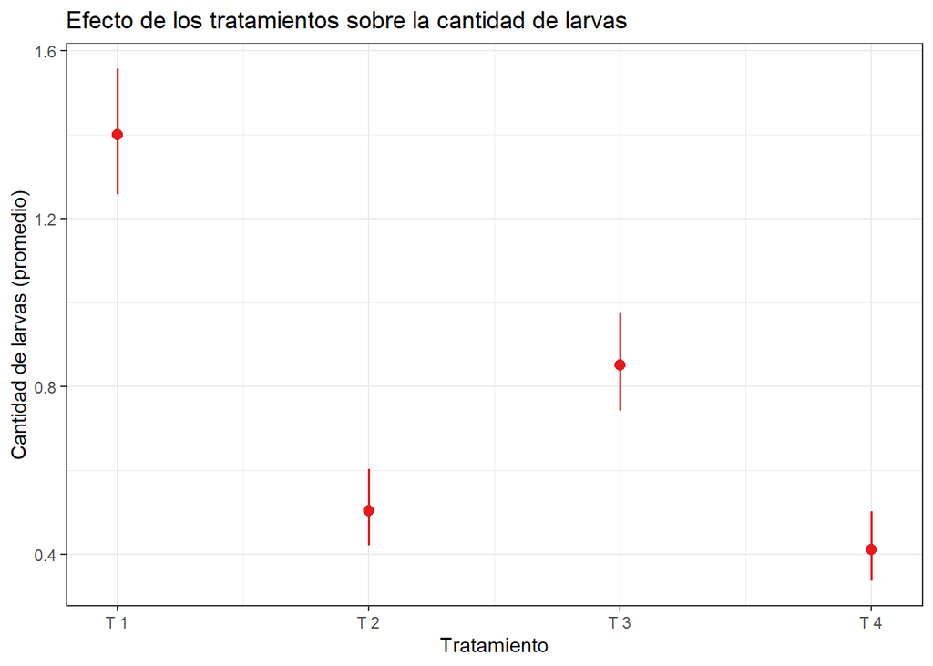

```r
plot_model(glm2_q,
           type = "pred",
           title = "Efecto de los tratamientos sobre la cantidad de larvas",
           axis.title = c("Tratamiento", "Cantidad de larvas (promedio)"),
           terms = "trt") +
  theme_bw()
```

Volver Arriba

Inicio

#### Gráfico de modelo con interacción

En el caso de que el modelo con interacción entre las variables fuese el que mejor se ajustó a nuestros datos.

```r
glm5_q <- glm(y ~ spray * lead, data = worms, family = quasipoisson)
```

```
## Ignoring unknown labels:
## • linetype : "lead"
## • shape : "lead"
```

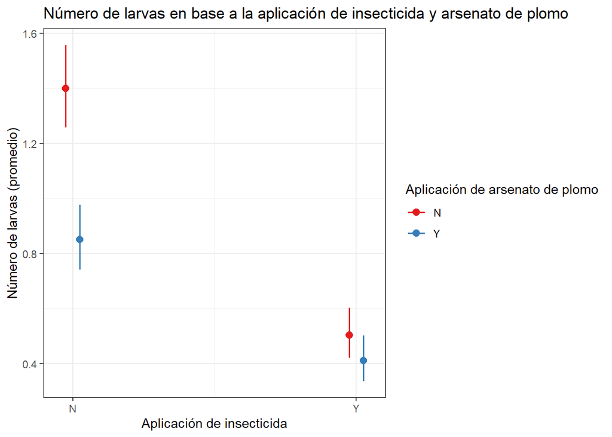

```r
plot_model(glm5_q,
           type = "int",
           terms = c("spray", "lead")) +
  aes(color = group) +
  labs(title = "Número de larvas en base a la aplicación de insecticida y arsenato de plomo",
       y = "Número de larvas (promedio)",
       x = "Aplicación de insecticida",
       color = "Aplicación de arsenato de plomo") +
  theme_bw()
```

Podemos verificar la interacción porque el número de larvas cuando no se aplica insecticida es diferente dependiendo de si se aplica o no se aplica arsenato de plomo; cuando si se aplica insecticida el número de larvas es similar cuando se aplica o no se aplica arsenato de plomo.

La interacción también puede verificarse con la función `interaction.plot()` del paquete base (cuando las variables predictoras son categóricas con pocos niveles):

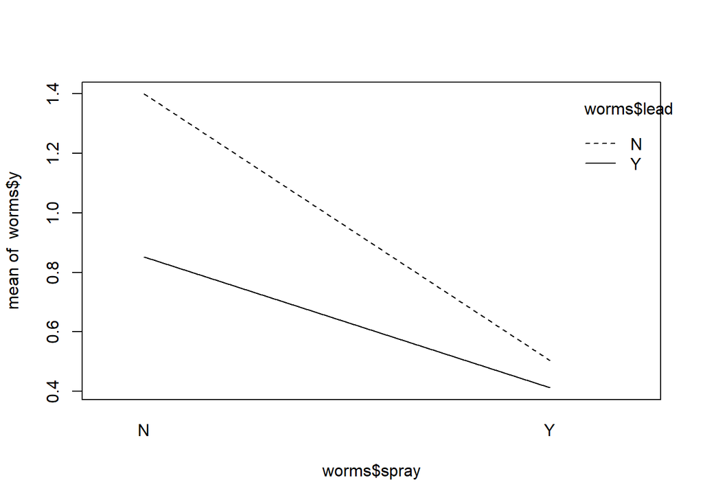

```r
interaction.plot(worms$spray, worms$lead, worms$y)
```

Si las líneas no son paralelas significa que hay una interaccion entre las variables. En este caso, las líneas no son paralelas, pero tampoco se cruzan, así que se puede decir que hay una leve interaccion entre la aplicación de insecticida y el tratamiento con arsenato de plomo que determina el efecto en el número de larvas.

Volver Arriba

Inicio

#### Ejemplo con otra base de datos

##### Datos

```r
mejillones <- import("data/muss.txt")
head(mejillones)
```

```
##   depth subs unio duck swan
## 1  0.08  mud    0    0    0
## 2  0.12  mud    0    0    0
## 3  0.14  mud    0    0    0
## 4  0.17  mud    0    0    0
## 5  0.18  mud    0    0    0
## 6  0.24  mud    0    1    0
```

Esta base de datos tiene conteos para tres especies diferentes de mejillones, hay una columna por especie (unio, duck y swan), y las variables evaluadas son la profundidad (depth) y el sustrato (subs).

Para este ejemplo desarrollaremos modelos para la especie swan ( *Anadara australis* ).

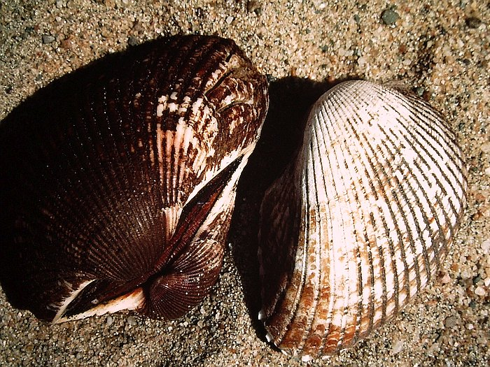

Como la variable de sustrato es de tipo caracter la convertimos a factor:

```r
mejillones$subs <- factor(mejillones$subs)
head(mejillones)
```

```
##   depth subs unio duck swan
## 1  0.08  mud    0    0    0
## 2  0.12  mud    0    0    0
## 3  0.14  mud    0    0    0
## 4  0.17  mud    0    0    0
## 5  0.18  mud    0    0    0
## 6  0.24  mud    0    1    0
```

##### Modelos

```r
modswan1 <- glm(swan ~ depth, family = poisson, data = mejillones)
modswan2 <- glm(swan ~ subs, family = poisson, data = mejillones)
modswan3 <- glm(swan ~ depth + subs, family = poisson, data = mejillones)
modswan4 <- glm(swan ~ depth * subs, family = poisson, data = mejillones)
```

##### Selección de modelos

```r
compare_performance(modswan1, modswan2, modswan3, modswan4, rank = TRUE)
```

```
## Following indices with missing values are not used for ranking: Sigma
```

```
## # Comparison of Model Performance Indices
##
## Name     | Model | Nagelkerke's R2 |  RMSE | Sigma | Score_log
## --------------------------------------------------------------
## modswan1 |   glm |           0.636 | 1.163 |     1 |    -1.295
## modswan3 |   glm |           0.648 | 1.149 |     1 |    -1.284
## modswan4 |   glm |           0.649 | 1.150 |     1 |    -1.283
## modswan2 |   glm |           0.228 | 1.488 |     1 |    -1.573
##
## Name     | Score_spherical | AIC weights | AICc weights | BIC weights | Performance-Score
## -----------------------------------------------------------------------------------------
## modswan1 |           0.087 |       0.694 |        0.732 |       0.971 |            84.09%
## modswan3 |           0.088 |       0.265 |        0.239 |       0.029 |            57.65%
## modswan4 |           0.088 |       0.041 |        0.029 |    3.49e-04 |            47.95%
## modswan2 |           0.090 |    8.96e-13 |     8.85e-13 |    3.50e-13 |            14.29%
```

```r
AICtab(modswan1, modswan2, modswan3, modswan4, base = TRUE, delta = TRUE, sort = TRUE, weights = TRUE)
```

```
##          AIC   dAIC  df weight
## modswan1 250.1   0.0 2  0.694
## modswan3 252.0   1.9 4  0.265
## modswan4 255.7   5.6 6  0.041
## modswan2 304.9  54.8 3  <0.001
```

##### Validación del mejor modelo

```r
check_overdispersion(modswan1)
```

```
## # Overdispersion test
##
##        dispersion ratio =  1.006
##   Pearson's Chi-Squared = 93.521
##                 p-value =  0.465
```

```
## No overdispersion detected.
```

```r
# No se detectó sobredispersión en el modelo
```

```r
check_zeroinflation(modswan1)
```

```
## # Check for zero-inflation
##
##    Observed zeros: 38
##   Predicted zeros: 38
##             Ratio: 1.00
```

```
## Model seems ok, ratio of observed and predicted zeros is within the
##   tolerance range.
```

```r
# No se detectó inflación de ceros en el modelo
```

##### Interpretación del mejor modelo

```r
summary(modswan1)
```

```
##
## Call:
## glm(formula = swan ~ depth, family = poisson, data = mejillones)
##
## Coefficients:
##             Estimate Std. Error z value Pr(>|z|)
## (Intercept)  -1.4387     0.2602  -5.529 3.23e-08 ***
## depth         1.1067     0.1358   8.150 3.64e-16 ***
## ---
## Signif. codes:  0 '***' 0.001 '**' 0.01 '*' 0.05 '.' 0.1 ' ' 1
##
## (Dispersion parameter for poisson family taken to be 1)
##
##     Null deviance: 176.40  on 94  degrees of freedom
## Residual deviance: 103.31  on 93  degrees of freedom
## AIC: 250.1
##
## Number of Fisher Scoring iterations: 5
```

```r
parameters(modswan1,
           exponentiate = TRUE)
```

```
## Parameter   |  IRR |   SE |       95% CI |     z |      p
## ---------------------------------------------------------
## (Intercept) | 0.24 | 0.06 | [0.14, 0.39] | -5.53 | < .001
## depth       | 3.02 | 0.41 | [2.33, 3.96] |  8.15 | < .001
```

```
##
## Uncertainty intervals (profile-likelihood) and p-values (two-tailed)
##   computed using a Wald z-distribution approximation.
```

De los modelos generados con una distribución de Poisson para explicar la varianza del número de mejillones, el que mejor se ajusta a los datos según el criterio de información de Akaike, es el modelo con la variable predictora de profundidad (“depth”).

Por cada metro que aumente la profundidad, el número de mejillones aumentará por un factor de 3.02 con un IC95% = 2.33, 3.96 (aumento del 202%, IC95% = 133%, 296%); p < 0.001, respecto al intercepto que es de 0.24 mejillones cuando la profundidad es de 0 metros.

También podemos interpretarlo de la siguiente manera:

```r
0.24*3.02
```

```
## [1] 0.7248
```

```r
performance(modswan1)
```

```
## # Indices of model performance
##
## AIC   |  AICc |   BIC | Nagelkerke's R2 |  RMSE | Sigma | Score_log | Score_spherical
## -------------------------------------------------------------------------------------
## 250.1 | 250.2 | 255.2 |           0.636 | 1.163 |     1 |    -1.295 |           0.087
```

El pseudo R cuadrado de Nagelkerke es de 0.636, lo que indica que la profundidad explica el 63.6% de la varianza del número de mejillones de esta especie, y el error del modelo (RMSE) es de 1.16 mejillones.

##### Gráfico del mejor modelo

```
## Data points may overlap. Use the `jitter` argument to add some amount of
##   random variation to the location of data points and avoid overplotting.
```

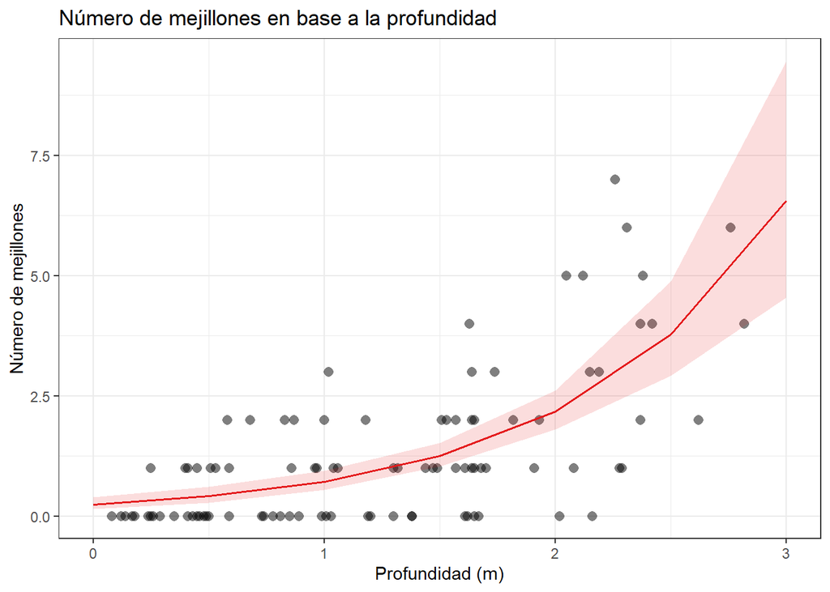

```r
plot_model(modswan1,
           type = "pred",
           show.data = TRUE,
           terms = "depth") +
  labs(title = "Número de mejillones en base a la profundidad",
       y = "Número de mejillones",
       x = "Profundidad (m)") +
  theme_bw()
```

Volver Arriba

Inicio